# Court Curb Analysis

## Calculating Distance From Each Branch

As Dr. Steigerwalt suggested, rather than making a complex ideological distance measure with all three branches, I am creating a separate variable for ideological distance for the court and each actor (Governor, lower chamber, upper chamber). These are simply taking the absolute difference between the branches then graphing to get a better idea.

```r
gavelCultureControl$court_gov_dist <- abs(gavelCultureControl$judicial - gavelCultureControl$governor)
gavelCultureControl$court_lower_dist <- abs(gavelCultureControl$judicial - gavelCultureControl$lower)
gavelCultureControl$court_upper_dist <- abs(gavelCultureControl$judicial - gavelCultureControl$upper)
```

The graphs below (which are eventually put into one grid) show the ideological distance for each relationship broken down by selection

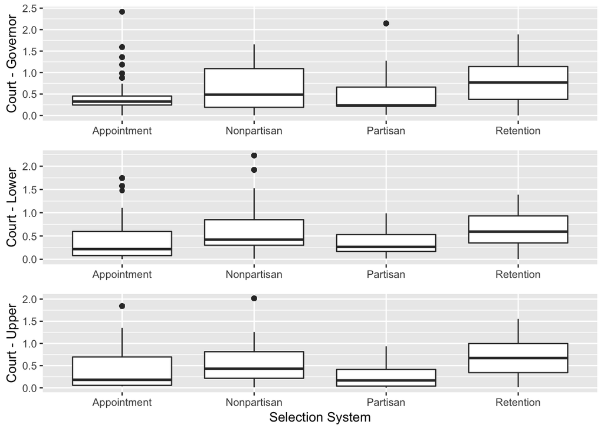

```r
a <- ggplot(data = gavelCultureControl) +
  geom_boxplot(aes(x = MoreDefined, y = court_gov_dist)) +
  xlab(NULL) +
  ylab("Court - Governor")
b <- ggplot(data = gavelCultureControl) +
  geom_boxplot(aes(x = MoreDefined, y = court_lower_dist)) +
  xlab(NULL) +
  ylab("Court - Lower")
c <- ggplot(data = gavelCultureControl) +
  geom_boxplot(aes(x = MoreDefined, y = court_upper_dist)) +
  xlab("Selection System") +
  ylab("Court - Upper")

grid.arrange(a,b,c)
## Warning: Removed 2364 rows containing non-finite values (stat_boxplot).
## Warning: Removed 111 rows containing non-finite values (stat_boxplot).
## Warning: Removed 1 rows containing non-finite values (stat_boxplot).
```

## Creating objects with time and average ideological distance

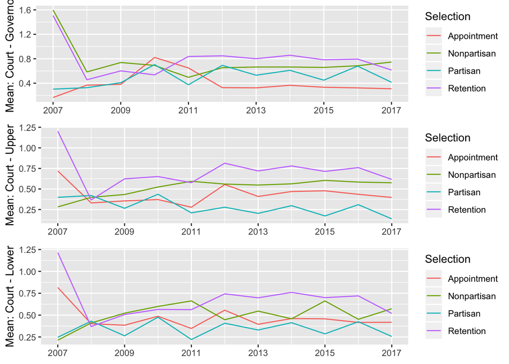

```r
ideology_gov_year <- gavelCultureControl %>%
  group_by(MoreDefined, Year) %>%
  filter(!is.na(court_gov_dist)) %>%
  summarise(govMean = mean(court_gov_dist))

ideology_upper_year <- gavelCultureControl %>%
  group_by(MoreDefined, Year) %>%
  filter(!is.na(court_upper_dist)) %>%
  summarise(upperMean = mean(court_upper_dist))

ideology_lower_year <- gavelCultureControl %>%
  group_by(MoreDefined, Year) %>%
  filter(!is.na(court_lower_dist)) %>%
  summarise(lowerMean = mean(court_lower_dist))

## graphing the data
d <- ggplot(data = ideology_gov_year) +
  geom_line(aes(x = Year, y = govMean, color = MoreDefined)) +
  scale_x_continuous(breaks = c(2007, 2009, 2011, 2013, 2015, 2017)) +
  xlab(NULL) +
  ylab("Mean: Court - Governor") +
  labs(colour = "Selection")

e <- ggplot(data = ideology_upper_year) +
  geom_line(aes(x = Year, y = upperMean, color = MoreDefined)) +
  scale_x_continuous(breaks = c(2007, 2009, 2011, 2013, 2015, 2017)) +
  xlab(NULL) +
  ylab("Mean: Court - Upper") +
  labs(colour = "Selection")

f <- ggplot(data = ideology_lower_year) +
  geom_line(aes(x = Year, y = lowerMean, color = MoreDefined)) +
  scale_x_continuous(breaks = c(2007, 2009, 2011, 2013, 2015, 2017)) +
  xlab(NULL) +
  ylab("Mean: Court - Lower") +
  labs(colour = "Selection")

# retention continues to be at teh high end of the list
grid.arrange(d,e,f)
```

### Graphing the Relationship between ideologicaly distance and court curbing

The code below creates scatter plots that show the relationship between ideological distance and court curbing legislation. Note the difference in scales! Unsurprisingly, there appears to be the weakest relationship between curbs and ideological distance between the Court and Governor.

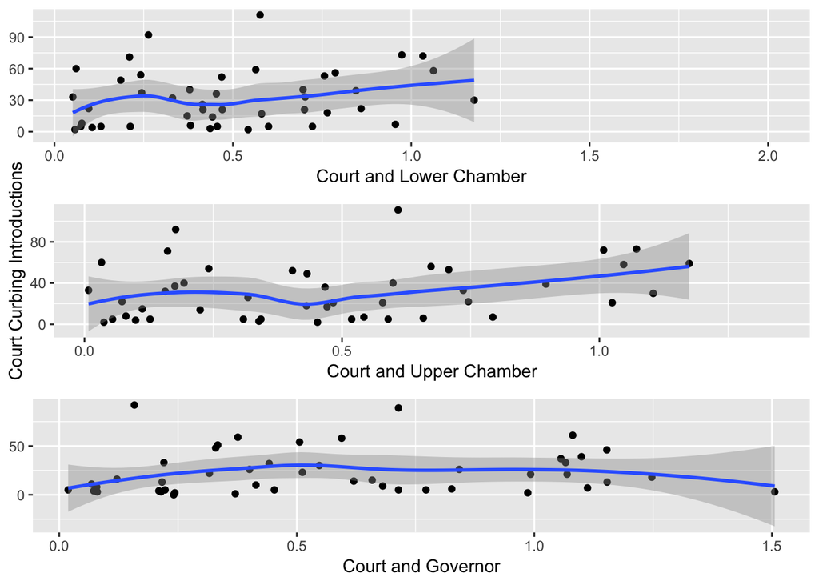

```r
g <- gavelCultureControl %>%
  group_by(Fullstate) %>%
  filter(!is.na(court_lower_dist)) %>%
  summarise(sum = sum(curbing),
            avg_ideology = mean(court_lower_dist)) %>%
  ggplot() +
  geom_point(aes(x = avg_ideology, y = sum)) +
  ylab(NULL) +
  xlab("Court and Lower Chamber") +
  geom_smooth(aes(x = avg_ideology, y = sum))


h <- gavelCultureControl %>%
  group_by(Fullstate) %>%
  filter(!is.na(court_upper_dist)) %>%
  summarise(sum = sum(curbing),
            avg_ideology = mean(court_upper_dist)) %>%
  ggplot() +
  geom_point(aes(x = avg_ideology, y = sum)) +
  ylab("Court Curbing Introductions") +
  xlab("Court and Upper Chamber") +
  geom_smooth(aes(x = avg_ideology, y = sum))

i <- gavelCultureControl %>%
  group_by(Fullstate) %>%
  filter(!is.na(court_gov_dist)) %>%
  summarise(sum = sum(curbing),
            avg_ideology = mean(court_gov_dist)) %>%
  ggplot() +
  geom_point(aes(x = avg_ideology, y = sum)) +
  ylab(NULL) +
  xlab("Court and Governor") +
  geom_smooth(aes(x = avg_ideology, y = sum))

grid.arrange(g, h, i)
```

The last chart deserves further exploration. I decided to also run the last plot, but this time only including enacted legislation. With the note that this is limited in the number of observations, I decided to graph it. The results still show really no relationship between ideological distance and curbs.

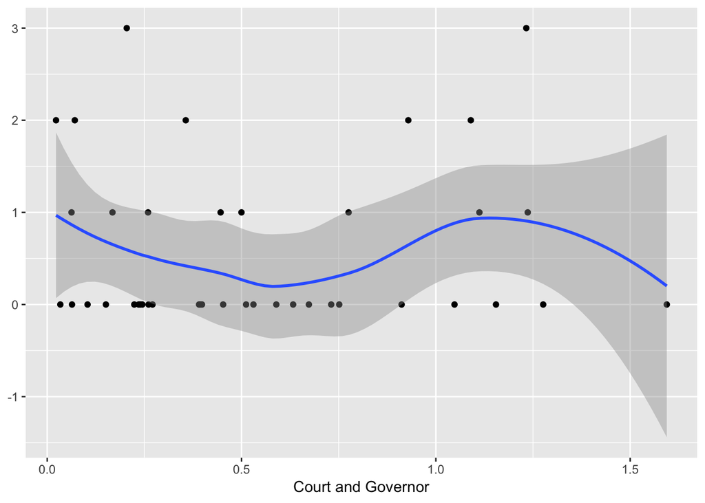

```r
gavelCultureControl %>%
  group_by(Fullstate) %>%
  filter(!is.na(court_gov_dist)) %>%
  filter(RichardLastAction == "Enacted") %>%
  summarise(sum = sum(curbing),
            avg_ideology = mean(court_gov_dist)) %>%
  ggplot() +
  geom_point(aes(x = avg_ideology, y = sum)) +
  ylab(NULL) +
  xlab("Court and Governor") +
  geom_smooth(aes(x = avg_ideology, y = sum))
```

# Model Prep

```r
count_data <- gavelCultureControl %>%
  filter(!(Year %in% c("2007", "43147"))) %>% # filtering out bad data
  group_by(State, Year) %>%
  mutate(curbs = sum(curbing)) %>%
  distinct(State, Year, .keep_all = TRUE) %>%
  arrange(State, Year)

count_data
```

```
## # A tibble: 475 x 38
## # Groups:   State, Year [475]
##    Fullstate State Type  `Bill Number`  Year Elected MoreDefined
##    <chr>     <chr> <chr> <chr>         <dbl> <chr>   <chr>
##  1 Alaska    AK    Other HB 411         2008 Elected Retention
##  2 Alaska    AK    Sala… SB 30          2009 Elected Retention
##  3 Alaska    AK    Sala… SB 30          2010 Elected Retention
##  4 Alaska    AK    Juri… HB 88          2011 Elected Retention
##  5 Alaska    AK    Sala… HB 299         2012 Elected Retention
##  6 Alaska    AK    Sala… HB 100         2013 Elected Retention
##  7 Alaska    AK    Sala… HB 100         2014 Elected Retention
##  8 Alaska    AK    Sele… SJR 3 (Const…  2015 Elected Retention
##  9 Alaska    AK    Other HB 11          2016 Elected Retention
## 10 Alaska    AK    Other HB 251         2017 Elected Retention
## # ... with 465 more rows, and 31 more variables: Description <chr>, `Last
## #   Action` <chr>, curbing <dbl>, RichardLastAction <chr>, `Richard
## #   Description` <chr>, `Date Signed` <dttm>, Unsure <dbl>, `Very
## #   interesting` <chr>, Notes <lgl>, election <chr>, judicial <dbl>,
## #   governor <dbl>, lower <dbl>, upper <dbl>, less <dbl>, more <dbl>,
## #   outside <dbl>, how_much_less <dbl>, how_much_more <dbl>,
## #   distance_closest_branch <dbl>, Moralistic <dbl>,
## #   Traditionalistic <dbl>, RepublicanLegslature <dbl>,
## #   SplitLegislature <dbl>, Culture <chr>, legislativeControl <chr>,
## #   unified <dbl>, court_gov_dist <dbl>, court_lower_dist <dbl>,
## #   court_upper_dist <dbl>, curbs <dbl>
```

Now I am adding in new “elected” variable as well as making columns for each election system broken down. This really should have happened earlier, but better late than never.

```r
count_data$elected <- ifelse(count_data$Elected == "Elected", 1, 0)
count_data$partisan <- ifelse(count_data$MoreDefined == "Partisan", 1, 0)
count_data$nonpartisan <- ifelse(count_data$MoreDefined == "Nonpartisan", 1, 0)
count_data$retention <- ifelse(count_data$MoreDefined == "Retention", 1, 0)
```

### Interacting Ideology and selection system

```r
count_data$elected_ideology_gov <- count_data$elected * count_data$court_gov_dist
count_data$elected_ideology_upper <- count_data$elected * count_data$court_upper_dist
count_data$elected_ideology_lower <- count_data$elected * count_data$court_lower_dist

count_data$partisan_ideology_gov <- count_data$partisan * count_data$court_gov_dist
count_data$partisan_ideology_upper <- count_data$partisan * count_data$court_upper_dist
count_data$partisan_ideology_lower <- count_data$partisan * count_data$court_lower_dist

count_data$nonpartisan_ideology_gov <- count_data$nonpartisan * count_data$court_gov_dist
count_data$nonpartisan_ideology_upper <- count_data$nonpartisan * count_data$court_upper_dist
count_data$nonpartisan_ideology_lower <- count_data$nonpartisan * count_data$court_lower_dist

count_data$retention_ideology_gov <- count_data$retention * count_data$court_gov_dist
count_data$retention_ideology_upper <- count_data$retention * count_data$court_upper_dist
count_data$retention_ideology_lower <- count_data$retention * count_data$court_lower_dist

summary(count_data$elected_ideology_gov)
```

```
##    Min. 1st Qu.  Median    Mean 3rd Qu.    Max.    NA's
## 0.00000 0.02216 0.32904 0.49155 0.77925 2.14575     117
```

```r
count_data$elected
```

[output not shown]

```r
count_data$court_gov_dist
```

```
##   [1]          NA          NA 0.986327537 0.986327537          NA
##   [6]          NA          NA          NA          NA          NA
##  [11] 0.164922769 0.142380496 0.517422769 0.571027863 0.050324762
##  [16] 0.050324762 0.050324762 0.050324762 0.050324762 0.050324762
##  [21] 1.097507522 0.114059255 1.380059255 1.380059255 1.380059255
##  [26]          NA          NA 0.511726274 0.511726274          NA
##  [31]          NA          NA          NA          NA          NA
##  [36] 0.366408829 0.366408829 1.140112401 1.140112401 0.793019562
##  [41] 0.793019562 0.793019562 0.793019562 0.793019562 0.793019562
##  [46] 0.779245424 0.779245424          NA          NA 0.769245424
##  [51] 0.769245424 0.769245424 0.769245424 0.769245424 0.769245424
##  [56] 0.452702919 0.452702919          NA          NA          NA
##  [61]          NA          NA          NA          NA          NA
##  [66] 0.004904836 0.004904836 0.091404836 0.091404836 0.091404836
##  [71] 0.091404836 0.091404836 0.091404836 0.091404836 0.091404836
```

[output cut: 80 more lines]

### Adding in Legislative Professionalization

```r
professionalization <- read_csv("ncsl professionalization.csv")
str(professionalization)
```

```
## Classes 'spec_tbl_df', 'tbl_df', 'tbl' and 'data.frame': 50 obs. of  2 variables:
##  $ State              : chr  "Alabama" "Alaska" "Arizona" "Arkansas" ...
##  $ Professionalization: num  3 4 3 3 5 3 3 3 3 3 ...
##  - attr(*, "spec")=
##   .. cols(
##   ..   State = col_character(),
##   ..   Professionalization = col_double()
##   .. )
```

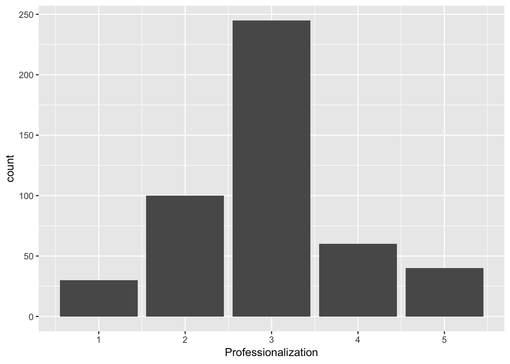

```r
count_data <- left_join(count_data, professionalization, by = c("Fullstate" = "State"))

# quick vizualization to check the data
ggplot(data = count_data) +
  geom_bar(aes(Professionalization))
```

I want to run another vizualization to test the data.

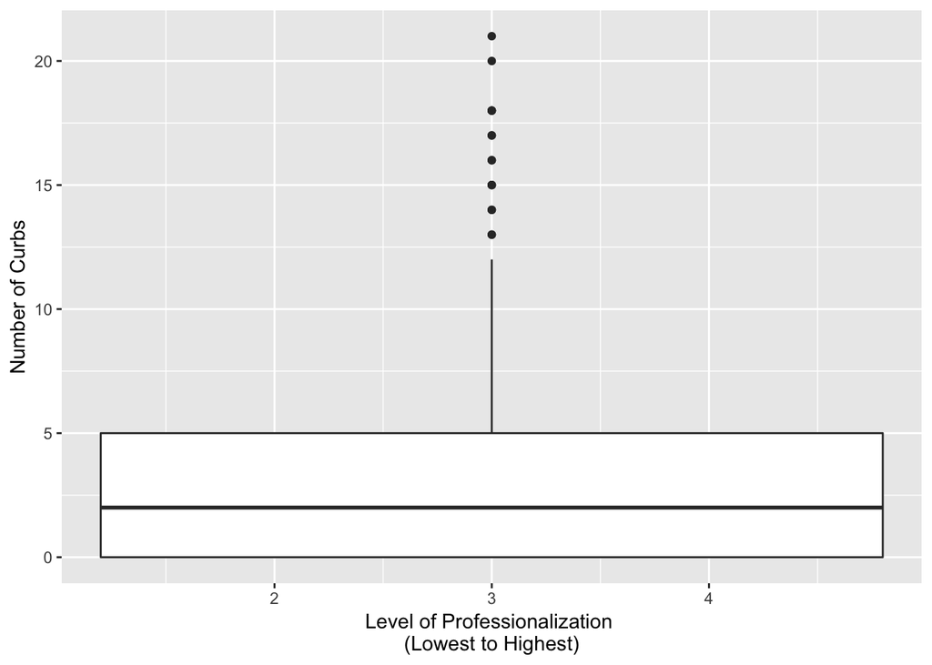

```r
ggplot(data = count_data) +
  geom_boxplot(aes(x = Professionalization, y = curbs, colour = Professionalization), show.legend = FALSE) +
  ylab("Number of Curbs") +
  xlab("Level of Professionalization \n(Lowest to Highest)")
```

## Last Data Cleaning

After meeting with Steigerwalt, I have decided to drop all observations where the legislature has not met. This is primarily made up of astates that meet every other year. To do this, I added dummy observations for the few instances where there was no legislation concerning courts that year.

```r
table(count_data$Year, count_data$Fullstate)
```

```
##
##        Alabama Alaska Arizona Arkansas California Colorado Connecticut
##   2008       1      1       1        0          1        1           1
##   2009       1      1       1        1          1        1           1
##   2010       1      1       1        0          1        1           1
##   2011       1      1       1        1          1        1           1
##   2012       1      1       1        0          1        1           1
##   2013       1      1       1        1          1        1           1
##   2014       1      1       1        0          1        1           1
##   2015       1      1       1        1          1        1           1
##   2016       1      1       1        0          1        1           1
##   2017       1      1       1        1          1        1           1
##
##        Delaware Florida Georgia Hawaii Idaho Illinois Indiana Iowa Kansas
##   2008        1       1       1      1     1        1       1    1      1
```

[output cut: 81 more lines]

This table shows the states for which there are no observations that year because they did not meet. The following table shows the number of instances for each state where I had to include dummy variables.

```r
table(gavelFull$Description == "No Legislation", gavelFull$State)
```

```
##
##          AK  AL  AR  AZ  CA  CO  CT  DE  FL  GA  HI  IA  ID  IL  IN  KS
##   FALSE  26 195 129 167 157  34 128  55 229 253 283 195  39 185 144 224
##   TRUE    0   0   0   0   0   1   0   0   0   0   0   0   1   0   0   0
##
##          KY  LA  MA  MD  ME  MI  MN  MO  MS  MT  NC  ND  NE  NH  NJ  NM
##   FALSE 119 164 286 162  48 141 245 246 220  73 228  32 110 193 294 147
##   TRUE    0   0   1   0   2   0   0   0   0   0   0   0   0   0   0   0
##
##          NV  NY  OH  OK  OR  PA  RI  SC  SD  TN  TX  UT  VA  VT  WA  WI
##   FALSE  75 491  64 432 126 359 143 340  28 631 396  83 169  32 208 149
##   TRUE    0   0   1   0   1   0   0   0   2   0   0   0   0   0   0   0
##
##          WV  WY
##   FALSE 292  54
##   TRUE    0   0
```